# Data Tidak Stasioner

#### Bagian 3

```r
dt_rg3 <- dt_rg[151:200] |> ts()
mean(dt_rg3)
```

```
## [1] 129.5688
```

```r
var(dt_rg3)
```

```
## [1] 711.8398
```

#### Plot Time Series

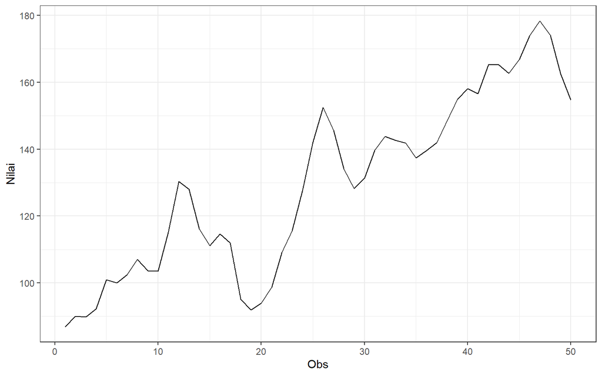

```r
dt_rg3 |> as_tsibble() |>
  ggplot(aes(x = index, y = value)) +
  geom_line() + theme_bw() +
  xlab("Obs") + ylab("Nilai")
```

Berdasarkan plot time series tersebut, terlihat bahwa data tidak stasioner dalam rataan karena masih terdapat tren pada data, namun cenderung stasioner dalam ragam karena memiliki lebar pita yang cenderung sama

#### Plot ACF

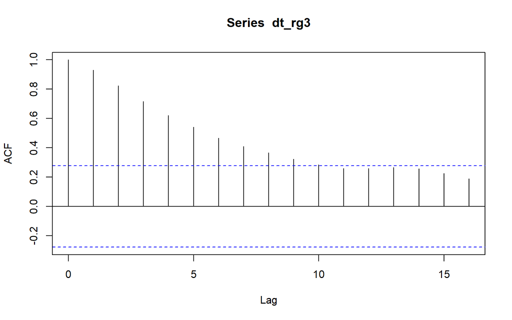

```r
acf(dt_rg3)
```

Berdasarkan plot ACF, terlihat bahwa plot ACF pada data tersebut menurun secara perlahan (*tails off slowly*)yang menandakan data tidak stasioner dalam rataan

#### Uji ADF

```r
tseries::adf.test(dt_rg3,k=5)
```

```
##
##  Augmented Dickey-Fuller Test
##
## data:  dt_rg3
## Dickey-Fuller = -3.1927, Lag order = 5, p-value = 0.0984
## alternative hypothesis: stationary
```

$H_0$ : Data tidak stasioner dalam rataan

$H_1$ : Data stasioner dalam rataan